# PEC4_diegoserranoventurini

[figure not shown]

M2.855 · Modelos avanzados de minería de datos · PEC4

2018-1 · Máster universitario en Ciencia de datos (Data science)

Estudios de Informática, Multimedia y Telecomunicación

# PEC 4: Combinación de clasificadores

En esta práctica veremos diferentes métodos de combinación de clasificadores aplicados sobre el conjunto de datos [Fashion MNIST](https://github.com/zalandoresearch/fashion-mnist) (ya usado en la práctica PEC 3).

0. Carga de datos
1. Combinación paralela de clasificadores base similares  
   1.1 Bagging  
   . 1.1.1 Random Forest simple  
   . 1.1.2 Out-of-bag  
   . 1.1.3 Probabilidad por clase  
   . 1.1.4 Importancia de las variables  
   . 1.1.5 Número de clasificadores  
   . 1.1.6 Volumen de datos  
   1.2 Boosting
2. Combinación secuencial de clasificadores base diferentes  
   2.1 Stacking  
   2.2 Cascading  
   . 2.2.1 Cascading simple  
   . 2.2.2 Cascading con variables adicionales

**Importante: Cada uno de los ejercicios puede suponer varios minutos de ejecución, por lo que la entrega debe hacerse en formato notebook y en formato html donde se vea el código y los resultados y comentarios de cada ejercicio. Para exportar el notebook a html puede hacerse desde el menú File $\to$ Download as $\to$ HTML.**

# 0. Carga de datos

Usaremos los mismos datos que en la práctica anterior, PEC 3, que son las 5.000 imágenes Fashion MNIST, correspondientes a 5 tipos de prendas de ropa distintos: "T-shirt", "Trouser", "Pullover", "Dress" y "Coat".

El siguiente código cargará las imágenes y mostrará un ejemplo de imagen de cada una de las clases:

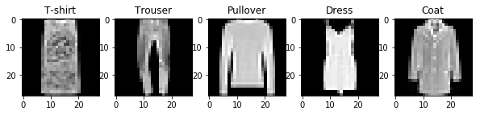

```python
import pickle
import numpy as np

with open("data.pickle", "rb") as f:
    data = pickle.load(f)

images = data["images"]
labels = data["labels"]
n_classes = 5
labels_text = ["T-shirt", "Trouser", "Pullover", "Dress", "Coat"]

import matplotlib.pyplot as plt
%matplotlib inline

fig, ax = plt.subplots(1, n_classes, figsize=(10,10))

idxs = [np.where(labels == i)[0] for i in range(n_classes)]

for i in range(n_classes):
    k = np.random.choice(idxs[i])
    ax[i].imshow(images[k].reshape(28, 28), cmap="gray")
    ax[i].set_title("{}".format(labels_text[i]))
```

Tal como en la PEC 3, reducimos dimensionalidad usando PCA:

```python
from sklearn.model_selection import train_test_split
from sklearn.decomposition import PCA

X_train, X_test, y_train, y_test = train_test_split(images, labels, test_size=0.2, random_state=2017, stratify=labels)

pca = PCA(n_components=100, random_state=2017)
pca_fit = pca.fit(X_train)
X_train_pca = pca_fit.transform(X_train)
X_test_pca = pca_fit.transform(X_test)
```

```python
# Imports
from sklearn.ensemble import RandomForestClassifier
from sklearn.model_selection import cross_val_score, validation_curve, learning_curve
from sklearn.metrics import accuracy_score
from sklearn.preprocessing import OneHotEncoder
import seaborn as sns
import pandas as pd
```

# 1. Combinación paralela de clasificadores base similares

## 1.1 Bagging

### 1.1.1 Random forest simple (1 punto)

La idea básica del *bagging* es utilizar el conjunto de entrenamiento original para generar centenares o miles de conjuntos similares usando muestreo con reemplazo. En este concepto está basado el algoritmo *Random Forest*, la combinación de varios árboles de decisión, cada uno entrenado con una realización diferente de los datos. La decisión final del clasificador combinado (la *Random Forest*) se toma por mayoría, dando el mismo peso a todas las decisiones parciales tomadas por los clasificadores base (los árboles).

**Implementación:** Usando los conjuntos *X_train_pca* e *y_train_pca*, entrenar un modelo *Random Forest* con 100 árboles de decisión y estimar la precisión del modelo con una estrategia de *cross-validation* en los mismos conjuntos.

Sugerencia: usar los módulos *RandomForestClassifier* y *cross_val_score* de sklearn. Para aprender más sobre *cross validation* y sobre como usar estes módulos, os recomendamos los siguientes enlaces:  
http://scikit-learn.org/stable/modules/generated/sklearn.ensemble.RandomForestClassifier.html  
http://scikit-learn.org/stable/modules/cross_validation.html  
http://scikit-learn.org/stable/modules/generated/sklearn.model_selection.cross_val_score.html

```python
# RandomForest training
rf = RandomForestClassifier(n_estimators=100, oob_score=True).fit(X=X_train_pca, y=y_train)
```

```python
scores = cross_val_score(rf, X_train_pca, y_train, cv=5)
print("Accuracy: %0.3f (+/- %0.3f)" % (scores.mean(), scores.std() * 2))
```

```
Accuracy: 0.866 (+/- 0.028)
```

### 1.1.2 Out-of-bag (1 punto)

Una ventaja del *bagging* usado en el *Random Forest* es que cada uno de los árboles de decisión ha sido entrenado con una combinación diferente de los datos (muestreo con reemplazo), o sea que cada uno de los árboles no ha visto una determinada parte de los datos originales. Esto define una especie de conjunto de test para cada uno de los árboles, llamado *out-of-bag*, que puede ser usado para estimar el error del modelo sin necesidad de usar el conjunto de test real que creamos previamente, ni de usar estrategias de *cross-validation*.

**Implementación:** Usando los conjuntos *X_train_pca* e *y_train_pca*, entrenar un modelo Random Forest con 100 árboles de decisión. Mostrar la precisión de este modelo en el *out-of-bag* y en el conjunto *X_test_pca*.

Sugerencia: usar el módulo *RandomForestClassifier* de sklearn. Para aprender más sobre *out-of-bag* y sobre como usar este módulo (incluyendo el atributo *oob_score_*), os recomendamos los siguientes enlaces:  
http://scikit-learn.org/stable/modules/generated/sklearn.ensemble.RandomForestClassifier.html  
http://scikit-learn.org/stable/auto_examples/ensemble/plot_ensemble_oob.html

*NOTA*: Usaremos el objeto modelo entrenado en el apartado anterior (`rf`)

```python
print("Out-of-bag error: %0.3f" % rf.oob_score_)
```

```
Out-of-bag error: 0.851
```

```python
rf_preds = rf.predict(X=X_test_pca)
print("Hold-out error: %0.3f" % accuracy_score(y_pred=rf_preds, y_true=y_test))
```

```
Hold-out error: 0.846
```

**Análisis:** La precisión obtenida en el *out-of-bag* y en el conjunto de test son comparables? Era de esperar?

Como podemos observar son precisiones similares.

Una de las caracteristicas del *bagging* es que genera mediante muestreo con remplazo observaciones artifiales para realizar el entrenamiento de cada uno de los estimadores. Esto permite que la metrica _out-of*bag (oob)* sea representativa del error real que puede cometer el modelo y por tanto comparable con la precision en el *hold-out* (test).

Es importante destacar que el muestreo que realiza esta tecnica tiene una limitacion y es que se basa en el conjunto de entrenamiento. Si las muestras de test y train son significativamente diferenciables el *oob* se calculara en unos individuos diferentes a los de test y, por tanto, no podremos comparar ambas metricas.

### 1.1.3 Probabilidad por clase (1 punto)

Otra ventaja del *bagging* usado en el *Random Forest* es que cada uno de los árboles de decisión, entrenado con una combinación diferente de los datos, puede obtener un resultado diferente. En los problemas de clasificación, el resultado de cada árbol se considera como un voto diferente, y la predicción final del modelo es la clase que haya obtenido más votos teniendo en cuenta todos los árboles.

Estos votos individuales de los árboles también se pueden usar para estimar la probabilidad con la que el modelo prevé cada una de las clases, siendo la probabilidad para cada clase igual al número de votos obtenidos para aquella clase dividido entre el número de árboles.

**Implementación:** Para cada clase (etiqueta), muestra un ejemplo de imágen que el modelo haya clasificado incorrectamente junto con la etiqueta asignada por el modelo y la etiqueta original. Muestra también las probabilidades que el modelo ha atribuído a cada clase para estas imágenes.

Sugerencia: usa el modelo que entrenaste en el ejercicio anterior con el módulo *RandomForestClassifier* de sklearn y las previsiones que calculaste para el conjunto de datos de test. Para mostrar las imágenes, usa el código proporcionado en la sección 0. Para aprender más sobre el módulo *RandomForestClassifier* de sklearn (incluyendo el método *predict_proba*), os recomendamos el siguiente enlace:  
http://scikit-learn.org/stable/modules/generated/sklearn.ensemble.RandomForestClassifier.html

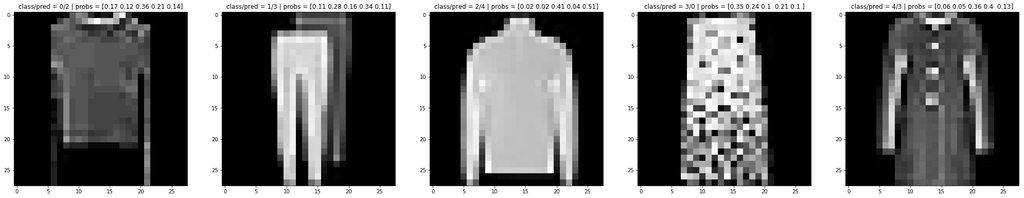

```python
fig, ax = plt.subplots(1, n_classes, figsize=(35,35))

for c in range(n_classes):
    img_wrong_class = rf_preds[(rf_preds != y_test) & (y_test == c)][0]
    img_corre_class = y_test[(rf_preds != y_test) & (y_test == c)][0]
    img_probs = rf.predict_proba(X_test_pca)[(rf_preds != y_test) & (y_test == c)][0]
    img = X_test[(rf_preds != y_test) & (y_test == c)][0].reshape(28, 28)
    ax[c].imshow(img, cmap="gray")
    ax[c].set_title("class/pred = {}/{} | probs = {}".format(img_corre_class, img_wrong_class, img_probs))
```

**Análisis:** En estos casos en los que el modelo se equivocó, estaba cerca de prever la etiqueta correcta?

En el primer y ultimo caso el modelo se queda lejos; sin embargo en los otros tres casos, el modelo no otorga mucha mas probabilidad a la etiqueta predicha que a la etiqueta real.

### 1.1.4 Importancia de las variables (1 punto)

Otra ventaja del algoritmo *Random Forest* es que permite medir la importancia relativa de cada variable, gracias a que cada uno de los árboles fué entrenado con un subconjunto diferente de las variables originales.

En el problema de clasificación de imágenes analizado aquí, la importancia de las variables nos permite saber cuáles son generalmente los píxeles más importantes par poder clasificar la imágen.

**Implementación:** Entrena un clasificador *Random Forest* con el conjunto de datos de entrenamiento original *X_train*, en los que cada variable es la intensidad de cada píxel (en vez de ser las variables PCA que usamos anteriormente). Muestra cuáles son las 10 variables más importantes. Haz un gráfico en el que se vea que zonas de una imágen son más importantes para el clasificador.

Sugerencia: usa el módulo *RandomForestClassifier* de sklearn para calcular la importancia de las variables. Para representar gráficamente la importancia de cada píxel de la imagen, usa parte del código proporcionado en la sección 0. Para aprender más sobre el módulo *RandomForestClassifier* de sklearn (incluyendo el método *feature_importances_*), os recomendamos el siguiente enlace:  
http://scikit-learn.org/stable/modules/generated/sklearn.ensemble.RandomForestClassifier.html

```python
rf_complete = RandomForestClassifier(n_estimators=100, n_jobs=-1).fit(X_train, y_train)
```

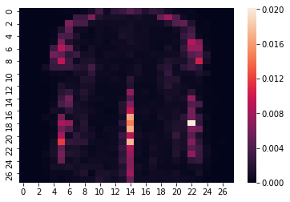

```python
pixel_imp = rf_complete.feature_importances_.reshape(28, 28)
sns.heatmap(data=pixel_imp)
```

**Análisis:** Te parece plausible el resultado que has obtenido? Porqué?

Si. Como vemos en la imagen los pixeles mas importantes son aquellos que delimitan el contorno de las prendas de ropa.

Lo que parecen en la mitad superior de la imagen unas "solapas" permiten diferenciar abrigos de jerseys o faldas. Por tanto esta representacion nos permite identificar aquellos puntos con informacion relevante para el modelo; y comprobar que las previsiones del modelo tienen sentido.

### 1.1.5 Número de clasificadores (1 punto)

En los ejercicios anteriores hemos combinado 100 clasificadores simples en nuestro clasificador combinado. Será que la precisión del clasificador combinado aumenta indefinidamente su desempeño si añadimos más clasificadores?

Para responder a esta pregunta vamos a representar una curva de validación. La curva de validación es una representación gráfica del desempeño de un modelo variando uno de sus parámetros. Mientras que la búsqueda de rejilla nos permite encontrar la combinación de parámetros que da mejores resultados, la curva de validación nos permite entender cuál es el impacto de un determinado parámetro en el desempeño de un modelo.

**Implementación:** Entrena varios modelos de *Random Forest* con un número de árboles cada vez mayor. Para cada modelo, calcula su precisón en el conjunto de test o usando *cross-validation* en el conjunto de entrenamiento. Opcional: representa gráficamente la evolución de la precisión con el número de árboles para ayudarte en el análisis de los resultados.

Sugerencia: usar el módulo *validation_curve* de sklearn. Para aprender a usar este módulo os recomendamos los siguientes enlaces:  
http://scikit-learn.org/stable/modules/generated/sklearn.model_selection.validation_curve.html  
http://scikit-learn.org/stable/modules/learning_curve.html#validation-curve

```python
rf_val_curve_results = []

for n_estimators in range(100, 5000, 250):

    rf_val_curve = RandomForestClassifier(n_estimators=n_estimators, n_jobs=-1).fit(X_train, y_train)

    accuracy = accuracy_score(y_pred=rf_val_curve.predict(X_test), y_true=y_test)

    rf_val_curve_results.append((n_estimators, accuracy))

    print("{:02.0f}% completed".format(100*n_estimators/5000))
```

```
02% completed
07% completed
12% completed
17% completed
22% completed
27% completed
32% completed
37% completed
42% completed
47% completed
52% completed
57% completed
62% completed
67% completed
72% completed
77% completed
82% completed
87% completed
92% completed
97% completed
```

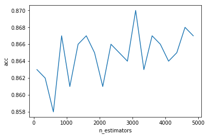

```python
rf_val_curve_results_pdf = pd.DataFrame(np.array(rf_val_curve_results), columns=["n_estimators", "acc"])
sns.lineplot(y=rf_val_curve_results_pdf["acc"], x=rf_val_curve_results_pdf["n_estimators"])
```

```
02% completed
07% completed
12% completed
17% completed
22% completed
27% completed
32% completed
37% completed
42% completed
47% completed
52% completed
57% completed
62% completed
67% completed
72% completed
77% completed
82% completed
87% completed
92% completed
97% completed
```

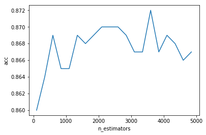

```python
rf_val_curve_results = []

for n_estimators in range(100, 5000, 250):

    rf_val_curve = RandomForestClassifier(n_estimators=n_estimators, n_jobs=-1).fit(X_train_pca, y_train)

    accuracy = accuracy_score(y_pred=rf_val_curve.predict(X_test_pca), y_true=y_test)

    rf_val_curve_results.append((n_estimators, accuracy))

    print("{:02.0f}% completed".format(100*n_estimators/5000))

rf_val_curve_results_pdf = pd.DataFrame(np.array(rf_val_curve_results), columns=["n_estimators", "acc"])
sns.lineplot(y=rf_val_curve_results_pdf["acc"], x=rf_val_curve_results_pdf["n_estimators"])
```

**Análisis:** Incrementa indefinidamente la precisión con el número de árboles combinados? Si satura, lo hace a la precisión máxima o a otro valor? Porqué?

Empleando el conjunto de dimensionalidad reducida no se aprecia una mejora significativa con el aumento del numero de arboles del modelo una vez se alcanzan los 1500 arboles. La razon fundamental es que estamos trabajando con pocas variables y practicamente el mismo numero de arboles que de imagenes. Esto provoca que la capacidad del modelo de *samplear* el dataset para generar registros artificiales con los que entrenarse es reducidad.

### 1.1.6 Volumen de datos (1 punto)

Será que entrenando el modelo con más datos (más imágenes) el modelo aprendería a clasificar con mejor precisión? Es muy útil intentar responder a esta pregunta antes de lanzarse a conseguir más datos, ya que este puede ser un proceso difícil, caro, o que implique esperar mucho tiempo.

Para responder a esta pregunta, analizaremos cómo evoluciona la precisión del modelo en los conjuntos de entrenamiento y test para diferentes volúmenes de datos de creciente tamaño. Representar los resultados en una curva de aprendizaje (*learning curve*) nos permitirá analizar visualmente estas cantidades.

**Implementación:** Entrena varios modelos de *Random Forest* con un volumen de datos cada vez mayor. Para cada modelo, calcula su precisón en el conjunto de entrenamiento y de test, y representa los resutados en un gráfico.

Sugerencia: usar el módulo *learning_curve* de sklearn. Para aprender a usar este módulo os recomendamos los siguientes enlaces:  
http://scikit-learn.org/stable/modules/learning_curve.html#learning-curve  
http://scikit-learn.org/stable/modules/generated/sklearn.model_selection.learning_curve.html

```python
# code extracted from https://scikit-learn.org/stable/auto_examples/model_selection/plot_learning_curve.html#sphx-glr-auto-examples-model-selection-plot-learning-curve-py
def plot_learning_curve(estimator, title, X, y, ylim=None, cv=None, n_jobs=None, train_sizes=np.linspace(.1, 1.0, 5)):
    """
    Generate a simple plot of the test and training learning curve.

    Parameters
    ----------
    estimator : object type that implements the "fit" and "predict" methods
        An object of that type which is cloned for each validation.

    title : string
        Title for the chart.

    X : array-like, shape (n_samples, n_features)
        Training vector, where n_samples is the number of samples and
        n_features is the number of features.

    y : array-like, shape (n_samples) or (n_samples, n_features), optional
        Target relative to X for classification or regression;
        None for unsupervised learning.

    ylim : tuple, shape (ymin, ymax), optional
        Defines minimum and maximum yvalues plotted.

    cv : int, cross-validation generator or an iterable, optional
        Determines the cross-validation splitting strategy.
        Possible inputs for cv are:
          - None, to use the default 3-fold cross-validation,
          - integer, to specify the number of folds.
          - :term:`CV splitter`,
          - An iterable yielding (train, test) splits as arrays of indices.

        For integer/None inputs, if ``y`` is binary or multiclass,
        :class:`StratifiedKFold` used. If the estimator is not a classifier
        or if ``y`` is neither binary nor multiclass, :class:`KFold` is used.

        Refer :ref:`User Guide <cross_validation>` for the various
        cross-validators that can be used here.

    n_jobs : int or None, optional (default=None)
        Number of jobs to run in parallel.
        ``None`` means 1 unless in a :obj:`joblib.parallel_backend` context.
        ``-1`` means using all processors. See :term:`Glossary <n_jobs>`
        for more details.

    train_sizes : array-like, shape (n_ticks,), dtype float or int
        Relative or absolute numbers of training examples that will be used to
        generate the learning curve. If the dtype is float, it is regarded as a
        fraction of the maximum size of the training set (that is determined
        by the selected validation method), i.e. it has to be within (0, 1].
        Otherwise it is interpreted as absolute sizes of the training sets.
        Note that for classification the number of samples usually have to
        be big enough to contain at least one sample from each class.
        (default: np.linspace(0.1, 1.0, 5))
    """
    plt.figure()
    plt.title(title)
    if ylim is not None:
        plt.ylim(*ylim)
    plt.xlabel("Training examples")
    plt.ylabel("Score")
    train_sizes, train_scores, test_scores = learning_curve(
        estimator, X, y, cv=cv, n_jobs=n_jobs, train_sizes=train_sizes)
    train_scores_mean = np.mean(train_scores, axis=1)
    train_scores_std = np.std(train_scores, axis=1)
    test_scores_mean = np.mean(test_scores, axis=1)
    test_scores_std = np.std(test_scores, axis=1)
    plt.grid()

    plt.fill_between(train_sizes, train_scores_mean - train_scores_std,
                     train_scores_mean + train_scores_std, alpha=0.1,
                     color="r")
    plt.fill_between(train_sizes, test_scores_mean - test_scores_std,
                     test_scores_mean + test_scores_std, alpha=0.1, color="g")
    plt.plot(train_sizes, train_scores_mean, 'o-', color="r",
             label="Training score")
    plt.plot(train_sizes, test_scores_mean, 'o-', color="g",
             label="Cross-validation score")

    plt.legend(loc="best")
    return plt
```

```
<module 'matplotlib.pyplot' from '/Users/diegoserrano/anaconda3/envs/uoc_mda/lib/python3.6/site-packages/matplotlib/pyplot.py'>
```

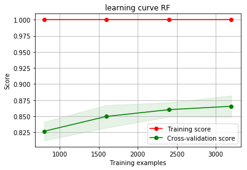

```python
plot_learning_curve(
    RandomForestClassifier(n_estimators=1500, n_jobs=-1), title="learning curve RF",
    X=X_train_pca, y=y_train, train_sizes=[0.25, 0.5, 0.75, 1.0], cv=5
)
```

**Análisis:** Crees que si obtuviésemos más datos de entrenamiento (más imágines clasificadas) mejoraría el modelo? Porqué?

En el grafico podemos observar que la diferencia entre la curva de entrenamiento y el error en validacion cruzada estan significativamente separadas. Esto indica que el modelo aun tiene una alta capacidad de mejora. Sin embargo vemos que la pendiente de la curva verde es bastante plana al final del eje x. Esta situacion quiere decir que aunque el modelo esta lejos de ser perfecto el aumentar mas el numero de registros de entrenamiento no produciria una gran mejora.

Otra informacion relevante extraible de este modelo es el grado de sobreentrenamiento en el conjunto de entrenamiento. Un modelo generalizable y robusto suele tener una curva de entrenamiento similar a la curva del resultado en el conjunto de validacion.

## 1.2 Boosting (1 punto)

En el sistema de *Boosting* se combinan varios clasificadores débiles sequencialmente, y en cada uno de ellos se da más peso a los datos que han sido erróneamente clasificados en las combinaciones anteriores, para que se concentre así en los casos más difíciles de resolver.

**Implementación:** Usando el conjunto *X_train_pca*, entrena un modelo Gradient Boosting y estima la precisión del modelo con una estrategia de *cross-validation* en los mismos conjuntos. Seguidamente calcula las previsiones del modelo en el conjunto *X_test_pca* y su precisión en este conjunto.

Sugerencia: usar los módulos *GradientBoostingClassifier* y *cross_val_score* de sklearn. Para aprender a usar este módulo os recomendamos el siguientes enlace:  
http://scikit-learn.org/stable/modules/generated/sklearn.ensemble.GradientBoostingClassifier.html

```python
from sklearn.ensemble import GradientBoostingClassifier
```

```python
gb_pca = GradientBoostingClassifier(learning_rate=0.01, max_depth=7, n_estimators=100).fit(X_train_pca, y_train)
```

```python
scores = cross_val_score(gb_pca, X_train_pca, y_train, cv=5)
print("Accuracy: %0.3f (+/- %0.3f)" % (scores.mean(), scores.std() * 2))
```

```
Accuracy: 0.827 (+/- 0.026)
```

**Análisis:** El boosting se basa en la combinación de clasificadores débiles. En la implementación que utilizaste en este ejercicio, cuál es la profundidad de los árboles utilizados? Compárala con la que utilizaste en los árboles de decisión del ejercicio de *bagging*.

Como se tratan de clasificadores debiles es necesario especificar la profundidad que queremos emplear. Esto no ocurre en el caso del *RandomForest* donde dejamos que los arboles "crecieran" hasta que las hojas fuera "puras". Por tanto, la profundidad de los estimadores es significativamente menor.

Por otro lado, el ensamblado que estamos construyendo emplea 100 estimadores, como en el caso del *RandomForest*.

## Boosting (extra)

El boosting es una tecnica de ensamblado que "gruesamente" se basa en construir un nuevo estimador debil en los errores del estimador anterior. Con esta filosofia en mente una tecnica menos conocida, que rigurosamente no es un ensamblado, son las *residual networks* o *ResNets*. Este tipo de redes neuronales surgieron en el campo de la vision por computador y sus resultados han sido impresionantes desde su concepcion.

Esencialmente consisten en crear bloques de capas donde el input es transformado por las capas de bloque obteniendo una representacion de si mismo. Al final del bloque, esta salida se suma a los datos originales, de esta manera se obtiene una representacion del error cometido al intentar realizar la prediccion. Esta representacion es la que se entrena en la red neuronal.

Su uso es menos conocido en campos tradicionales de la mineria de datos pero por completitud vamos a probar la tecnica con los datos proporcionados

```python
import numpy as np
import torch
import torch.nn as nn
import torch.nn.functional as F
from torch.autograd import Variable
from torch.utils.data import DataLoader


class BoostingNet(nn.Module):

    _loss_function = None
    _optimizer = None
    optimizer = None

    def __init__(self, inputCols=None, outputCol=None, n_input=None, boosting_stack=0, hidden_layers=None, n_output=None, optimizer=None, loss_function=None):

        super(BoostingNet, self).__init__()

        self.features_names = inputCols
        self.target_name = outputCol
        self._optimizer = optimizer
        self._loss_function = loss_function

        self.boosting_fc_stack = nn.ModuleList(
            [nn.Linear(n_input, n_input) for i in range(boosting_stack)]
        )
        self.boosting_bn_stack = nn.ModuleList(
            [nn.BatchNorm1d(n_input) for i in range(boosting_stack)]
        )

        self.fc_stack = nn.ModuleList(
            [nn.Linear(n_input, hidden_layers[0])] +
            [nn.Linear(hidden_layers[i], hidden_layers[i+1]) for i in range(0, len(hidden_layers)-1)]
        )
        self.bn_stack = nn.ModuleList(
            [nn.BatchNorm1d(hidden) for hidden in hidden_layers]
        )
        self.fc_out = nn.Linear(hidden_layers[-1], n_output)

    def forward(self, features_t):

        out = features_t
        for linear, bn in zip(self.boosting_fc_stack, self.boosting_bn_stack):
            out = linear(out)
            out = bn(out)
            out += features_t
            out = F.relu(out)

        for linear, bn in zip(self.fc_stack, self.bn_stack):
            out = linear(out)
            out = bn(out)
            out = F.relu(out)

        out = self.fc_out(out)
        out = F.log_softmax(out)

        return out

    def set_loss_function(self, loss_function):
        self._loss_function = loss_function
        return self

    def set_optimizer(self, optimizer, **args):
        if self._optimizer is None:
            self._optimizer = optimizer
        else:
            _optimizer = optimizer(**args)
            self.optimizer = _optimizer
        return self

    def build_net(self, loss_function, optimizer):
        return self.set_loss_function(loss_function).set_optimizer(optimizer)

    def fit(self, train_df, batch_size=64, num_epochs=1, init_lr=0.01):

        if not self.features_names or not self.target_name:
            raise Exception("Target and feature columns must be set before training")

        tensor_dataset = self._get_tensor_dataset(train_df)

        loader = DataLoader(dataset=tensor_dataset, batch_size=batch_size, shuffle=True)

        losses = []
        for epoch in range(num_epochs):

            self.set_optimizer(self._optimizer, params=self.parameters(), lr=init_lr)

            for i, (images, labels) in enumerate(loader):
                images = Variable(images.float())
                labels = Variable(labels.long())

                # forward pass
                loss = self._forward_pass(images, labels)

                # backward pass
                loss.backward()

                # calculate the gradients
                self.optimizer.step()

                # log the losses
                losses.append(loss.item())
                if (i+1) % 100 == 0:
                    print('Epoch : %d/%d, Iter : %d/%d,  Loss: %.4f' % (epoch+1, num_epochs, i+1, len(tensor_dataset)//batch_size, loss.data[0]))
        return self

    def _get_tensor_dataset(self, train_df):

        features_df = train_df[self.features_names]
        features_tensor = torch.Tensor(features_df).float()

        target_df = train_df[self.target_name]
        target_tensor = torch.Tensor(target_df)

        return torch.utils.data.TensorDataset(features_tensor, target_tensor)

    def _forward_pass(self, features, label):
        # restart the gradient calculations
        self.optimizer.zero_grad()

        # Forward pass
        outputs = self(features)

        # calculate the loss function
        criterion = self._loss_function()
        loss = criterion(outputs, label)

        return loss

    def predict(self, features):
        features_tensor = torch.Tensor(features)

        predictions = np.argmax(F.log_softmax(self(features_tensor)).data.numpy(), axis=1)

        return predictions
```

```python
import torch
import torch.nn as nn
from sklearn.model_selection import train_test_split
from sklearn.decomposition import PCA
from sklearn.metrics import confusion_matrix, balanced_accuracy_score


def test_resnet():

    images_train = {"images": X_train_pca, "labels": y_train}

    net = BoostingNet(n_input=X_train_pca.shape[1], hidden_layers=[64, 32], n_output=5, boosting_stack=1,
                      inputCols="images", outputCol="labels").\
        build_net(optimizer=torch.optim.Adam, loss_function=nn.CrossEntropyLoss)

    net.fit(images_train, batch_size=64, num_epochs=20, init_lr=0.01)
    predictions = net.predict(X_test_pca)

    print("Hold-out error: %0.3f" % accuracy_score(y_pred=predictions, y_true=y_test))

    return net


net = test_resnet()
```

```
Hold-out error: 0.868
```

Vemos que los resultados del modelo son ligeramente superiores a los obtenidos por el *gradientBoosting* y el *randomForest* sin realizar una intensiva optimizacion de los hiperparametros.

# 2. Combinación secuencial de clasificadores base diferentes

## 2.1 Stacking (1 punto)

Un clasificador de *stacking* usa como atributos las predicciones hechas por otros clasificadores en lugar de los datos originales de entrada.

Para construir nuestro clasificador de *stacking* vamos a usar las predicciones hechas en el conjunto de test por los clasificadores:

- utilizados en los ejercicios anteriores en la PEC 4
- los utilizados en la PEC 3 (K-Nearest neighbors Classifier (knc), Support Vector Machines Classifier (svmc) y Neural Network Classifier (nnc))
- Discriminant Analysis (dac)

los dos últimos os los damos en archivos adjuntos. Estas predicciones se pueden cargar con el siguiente código:

```python
# carga de predicciones calculadas en el PEC3:
preds_knc = np.load("../../data/preds_knc.pickle")
preds_svmc = np.load("../../data/preds_svmc.pickle")
preds_nnc = np.load("../../data/preds_nnc.pickle")
# carga de las predicciones por un modelo de Discriminant Analysis:
preds_dac = np.load("../../data/preds_dac.pickle")
```

**Implementación:** Construye un clasificador de *stacking* usando una *Random Forest* que use como atributos a las predicciones hechas en el conjunto de test por los algoritmos k-nn, SVM, red neuronal y Gradient Boosting. Calcula la precisión del modelo resultante con *cross-validation* en el conjunto de test.

Sugerencia: usar las funciones column_stack de numpy y OneHotEncoder de sklearn para preparar los datos. Para aprender a usar estas funciones os recomendamos los siguientes enlaces:  
https://docs.scipy.org/doc/numpy-1.14.0/reference/generated/numpy.column_stack.html  
http://scikit-learn.org/stable/modules/generated/sklearn.preprocessing.OneHotEncoder.html  
http://scikit-learn.org/stable/modules/preprocessing.html#encoding-categorical-features

```python
preds_rf = rf.predict(X_test_pca)
preds_gb = gb_pca.predict(X_test_pca)
```

```python
predictions_df = pd.DataFrame(np.column_stack((preds_dac, preds_knc, preds_nnc, preds_svmc, preds_rf, preds_gb)),
                              columns=["dac", "knc", "nnc", "svc", "rfc", "gbc"])
```

```python
encoder = OneHotEncoder(sparse=False)
```

```python
X_preds = encoder.fit_transform(predictions_df)
```

```python
scores = cross_val_score(RandomForestClassifier(n_estimators=100), X_preds, y_test, cv=5)
print("Accuracy: %0.3f (+/- %0.3f)" % (scores.mean(), scores.std() * 2))
```

```
Accuracy: 0.881 (+/- 0.023)
```

**Análisis:** Has conseguido mejorar la precisión gracias al *stacking*? Comenta el resultado.

El resultado que se muestra es mejor que los proporcionados por los modelos individuales.

Esta precision es unicamente comparable con la obtenida con el resto de `cross_val_score` que hemos calculado durante la practica, y es imporante destacar que no es el mismo conjunto por lo que no es una precision 100% comparable.

La forma 100% correcta de realizar este procedimiento es haber entrenado digamos con un X% de los datos, realizar estas previsiones y segundo entrenamiento en el Y% y calcular la precision de los modelos individuales y del modelo combinado en el Z% restante siendo $X + Y + Z = 100\%$

## 2.2 Cascading

### 2.2.1 Cascading simple (1 punto)

El caso de *cascading* es parecido al de *stacking* pero utilizando no solamente las predicciones parciales de los clasificadores base, sino también los datos originales.

**Implementación:** Construye un clasificador de *cascading* usando una *Random Forest* que use como atributos a las predicciones hechas en el conjunto de test por los algoritmos k-nn, SVM, red neuronal y Gradient Boosting, así como también las variables originales. Calcula la precisión del modelo resultante con *cross-validation* en el conjunto de test.

Sugerencia: Usa el mismo conjunto de datos que en el ejercicio anterior pero añade el conjunto de test original *X_test_pca*.

```python
X_cascading = np.column_stack(tup=(X_preds, X_test_pca))
```

```python
scores = cross_val_score(RandomForestClassifier(n_estimators=100), X_cascading, y_test, cv=5)
print("Accuracy: %0.3f (+/- %0.3f)" % (scores.mean(), scores.std() * 2))
```

```
Accuracy: 0.888 (+/- 0.034)
```

**Análisis:** Has conseguido mejorar la precisión gracias al *cascading*? Comenta el resultado.

Los resultados obtenidos son ligeramente mejores que con el *stacking*. Como veiamos en la grafica _validation*curve* un numero bajo de estimadores no esta aun saturado. Esto permite que al anhadir mas informacion al modelo incluyendo las variables originales podamos aranhar puntos de precision

### 2.2.2 Cascading con variables adicionales (1 punto)

En el *cascading* también podemos añadir como variables del modelo a datos adicionales que se hayan podido generar durante la toma de decisiones de los clasificadores que combinamos.

**Implementación:** Qué datos adicionales de los modelos anteriores podrías usar para enriquecer al modelo? Construye un clasificador de *cascading* usando una *Random Forest* que use como atributos a los usados en el ejercicio anterior más otros que puedas obtener de algunos de los clasificadores utilizados en los ejercicios anteriores. Calcula la precisión del modelo resultante con *cross-validation* en el conjunto de test.

En primer lugar vamos a incluir las predicciones del modelo *ResNet*.

```python
preds_resnet = net.predict(X_test_pca)
```

```python
X_cascading_full = np.column_stack((X_cascading, preds_resnet))

scores = cross_val_score(RandomForestClassifier(n_estimators=100), X_cascading_full, y_test, cv=5)
print("Accuracy: %0.3f (+/- %0.3f)" % (scores.mean(), scores.std() * 2))
```

```
Accuracy: 0.893 (+/- 0.036)
```

**Análisis:** Has conseguido mejorar la precisión gracias a añadir datos adicionales al *stacking*? Comenta el resultado.

Vemos que la mejora del modelo es ligera anhadiendo las predicciones de la red neuronal (aunque hemos aumentado la `sd` del error).

Puesto que todas las variables que estamos anhadiendo contienen la "misma" informacion, el modelo puede estar ligeramente saturado en este punto. Puesto que estamos empleando el conjunto de dimensionalidad reducida, podriamos cambiar de conjunto de entrenamiento y emplear el conjunto original y testear la capacidad de mejora del modelo al anhadir mas informacion en dicho conjunto